# DES_part6_03735990

## 6.2 Verification

```python
#Task 6.2

%run "part6_tests"
```

```
.
----------------------------------------------------------------------
Ran 1 test in 0.016s

OK
```

### Task 6.2.1: Chi Square Test

```python
# Task 6_2_1 Chi Square Test

import part6_simstudy

part6_simstudy.task_6_2_1()
```

```
Test for Mean : 0 Variance : 1
Passed!
```

## 6.3 Analysis and General Questions

### Task 6.3.1: Chi Square Test

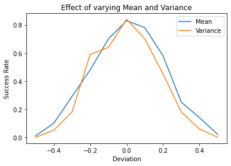

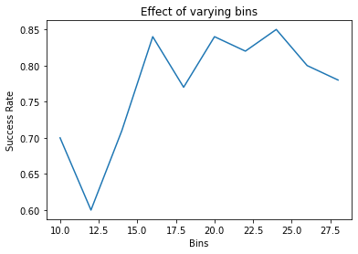

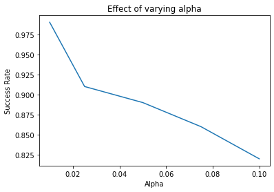

```python
# Task 6_3_1 Effects of varying parameters

import part6_simstudy

part6_simstudy.task_6_3_1_1()
part6_simstudy.task_6_3_1_2()
part6_simstudy.task_6_3_1_3()
```

The above plots were generated by runnning the test 100 times for each set of input parameters and observing the succes rate of the test. Note, that all other parameters are kept while varying the ones whose effect we wish to observe. From the above plots and tests the effect of varying the input parameters to the tests can be observed:

1. If we change the mean and/or the variance of the samples but still compare them to the standard normal distribution in the test, the success probability drops as we deviate more from values given to the standard normal distribuition in the test. This is ecpected as we are comparing slightly different distributions.
2. We see a general trend that as we increase the number of bins, the success rate of the test increases. However, as we increase the bins more than 20 we dont see a linear improvement in the success probabiltiy. We also see some drops due to the randomness of the generated distributions.
3. As we increase alpha, we get lowet sucess rate and this is because the alpha is like a tolerance to samples. We are allowing deviations with alpha, and as we make this allowed window smaller, we will get more failed tests and hence, the success rate will drop.